# Final Project

# ARIMA Modelling

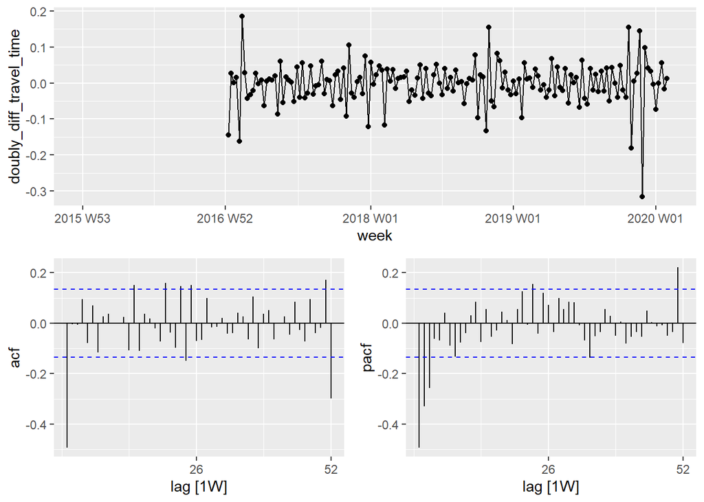

```r
avg_times_week %>% gg_tsdisplay(doubly_diff_travel_time,plot_type = "partial",lag=52)
```

Here we are seeing some minor spikes. The significant spike at lag 1 in the ACF suggests a non-seasonal MA(1) component. The significant spike at lag 52 in the ACF suggests a seasonal MA(1) component. Consequently, we begin with an ARIMA(0,1,1)(0,1,1)52 model, indicating a first difference, a seasonal difference, and non-seasonal MA(1) and seasonal MA(1) component. If we had started with the PACF, we may have selected an ARIMA(3,1,0)(0,1,1)52 model — using the PACF to select the non-seasonal part of the model and the ACF to select the seasonal part of the model. We will also include an automatically selected model.

```r
fit <- avg_times_week %>%
  model(arima011011 = ARIMA(mean_travel_time ~ pdq(0,1,1) + PDQ(0,1,1)),
    arima310010 = ARIMA(mean_travel_time ~ pdq(3,1,0) + PDQ(0,1,1)),
    auto = ARIMA(mean_travel_time, stepwise = FALSE, approx = FALSE))
```

```r
res <- fit %>% pivot_longer(everything(), names_to = "Model name",
                     values_to = "Orders")
```

```r
res
```

```
## # A mable: 3 x 2
## # Key:     Model name [3]
##   `Model name`                             Orders
##   <chr>                                   <model>
## 1 arima011011           <ARIMA(0,1,1)(0,1,1)[52]>
## 2 arima310010           <ARIMA(3,1,0)(0,1,1)[52]>
## 3 auto         <ARIMA(1,0,1)(1,1,0)[52] w/ drift>
```

```r
glance(fit) %>% arrange(AICc) %>% select(.model:BIC)
```

```
## # A tibble: 3 × 6
##   .model      sigma2 log_lik   AIC  AICc   BIC
##   <chr>        <dbl>   <dbl> <dbl> <dbl> <dbl>
## 1 arima011011  1826.   -843. 1693. 1693. 1702.
## 2 arima310010  1749.   -843. 1695. 1696. 1711.
## 3 auto         1871.   -847. 1703. 1703. 1718.
```

We can observe that the ARIMA(0,1,1)(0,1,1)52 model we predicted is performing the best with the lowest AIC. We can further confirm it by looking at its residual diagnostics.

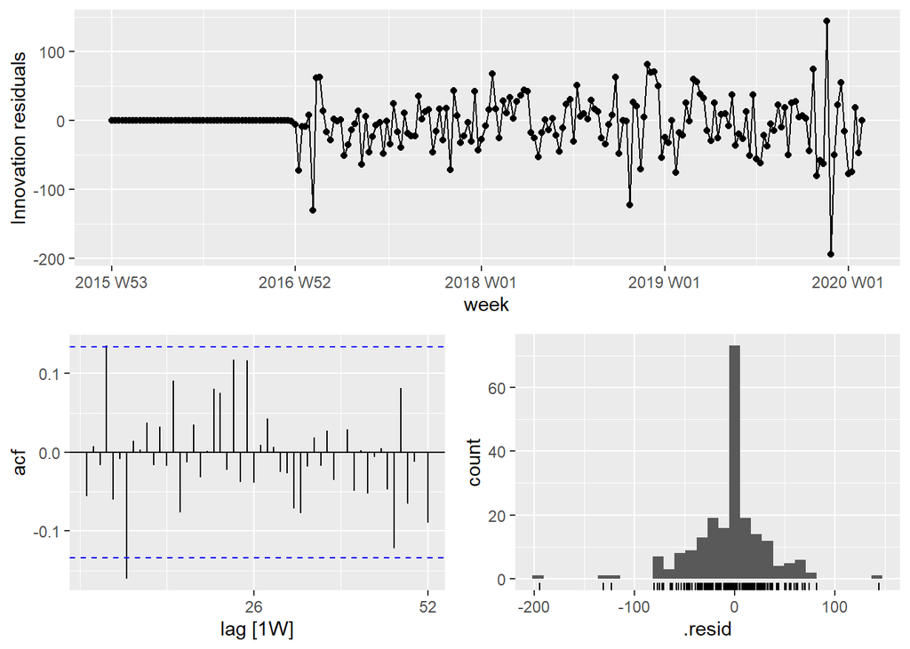

```r
fit %>% select(arima011011) %>% gg_tsresiduals(lag=52)
```

We can see that there is no information left in the residuals, so the model is performing well.

```r
augment(fit) %>% filter(.model == "arima011011") %>%
  features(.innov, ljung_box, lag=52, dof=2)
```

```
## # A tibble: 1 × 3
##   .model      lb_stat lb_pvalue
##   <chr>         <dbl>     <dbl>
## 1 arima011011    42.7     0.758
```

On performing Ljung-Box test, we get a high p-value which confirms our residuals are white noise.

```r
augment(fit) %>% filter(.model == "auto") %>%
  features(.innov, ljung_box, lag=52, dof=6)
```

```
## # A tibble: 1 × 3
##   .model lb_stat lb_pvalue
##   <chr>    <dbl>     <dbl>
## 1 auto      37.1     0.822
```

## ARIMA Forecasting

We will perform ARIMA forecasting of mean travel times with the best fitted model.

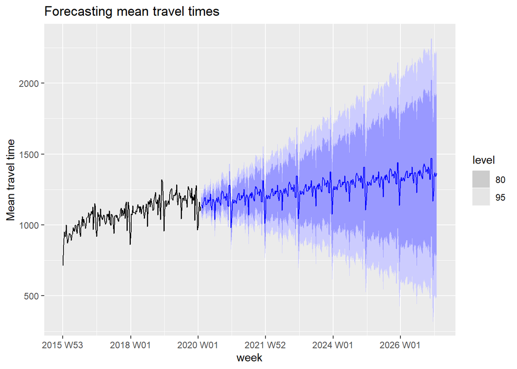

```r
forecast(fit,h=365) %>%
  filter(.model=='arima011011') %>% autoplot(avg_times_week) +
  labs(title = "Forecasting mean travel times",
       y="Mean travel time")
```

We can see that the ARIMA model is able to correctly capture the yearly seasonality. With respect to trend, its predicting high traffic flow which means high Uber demand in the coming years.

# Dynamic Harmonic Progression

When there are long seasonal periods, a dynamic regression with Fourier terms is often better than other models. Seasonal pattern is modelled using Fourier terms with short-term time series dynamics handled by an ARMA error.

```r
fit_harmonic <- avg_times_ts %>% model(
  dhr = ARIMA(sqrt(mean_travel_time) ~ PDQ(0,0,0) + pdq(d=0)+
    fourier(period=7,K=3)+
    fourier(period=30,K=2))
)

fc_fit_harmonic <- fit_harmonic %>% forecast(h=365)
```

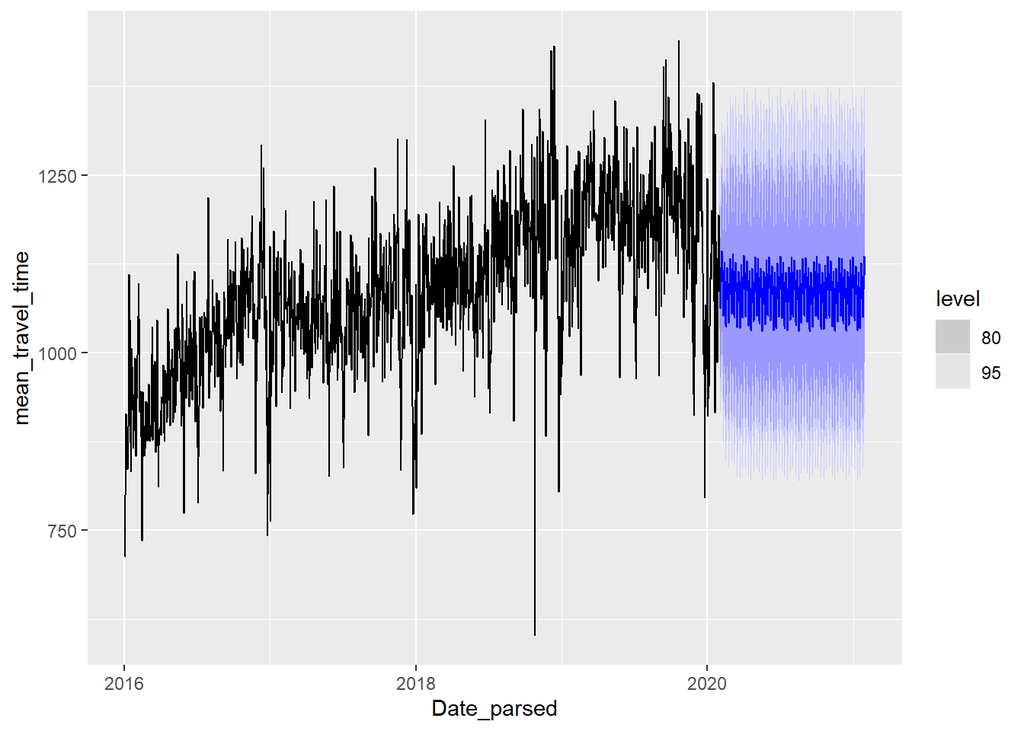

```r
fc_fit_harmonic %>% autoplot(avg_times_ts)
```

```r
fit_hr <- model(avg_times_week,
                `K = 7` = ARIMA(log(mean_travel_time) ~ fourier(K=7) + PDQ(0,0,0)),
                `K = 8` = ARIMA(log(mean_travel_time) ~ fourier(K=8) + PDQ(0,0,0)),
                `K = 9` = ARIMA(log(mean_travel_time) ~ fourier(K=9) + PDQ(0,0,0)),
                `K = 10` = ARIMA(log(mean_travel_time) ~ fourier(K=10) + PDQ(0,0,0)),
                `K = 11` = ARIMA(log(mean_travel_time) ~ fourier(K=11) + PDQ(0,0,0)),
                `K = 12` = ARIMA(log(mean_travel_time) ~ fourier(K=12) + PDQ(0,0,0))
                 )
```

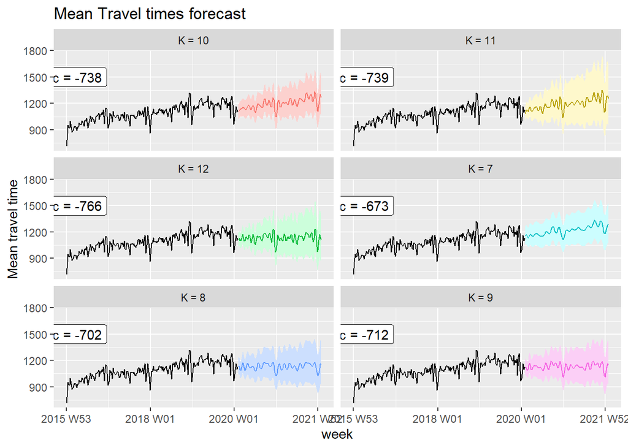

```r
fit_hr %>% forecast(h="2 years") %>% autoplot(avg_times_week,level=95) +
  facet_wrap(vars(.model),ncol=2)+
  guides(colour="none",fill="none",level="none")+
  geom_label(
    aes(x = yearweek("2015 W53"), y = 1500,
        label = paste0("AICc = ", format(AICc))),
    data = glance(fit_hr))+
  labs(title= "Mean Travel times forecast",
       y="Mean travel time")
```

The AIC value is the least for K=12. The forecasts are also able to capture the seasonality.

# Prophet Modelling

```r
#install.packages("fable.prophet")
library(fable.prophet)
train_wk <- slice(avg_times_week,1:(n()-60))
#train <- as_tsibble(train,index=Date_parsed)
#train <- fill_gaps(train,mean_travel_time = mean(mean_travel_time))
```

```r
fit_prop <- train_wk %>% model (
  arima = ARIMA(mean_travel_time),
  prophet = prophet(mean_travel_time ~ season(period=52,order=10,type="multiplicative"))
)

fc_prop <- fit_prop %>% forecast(h=60)
```

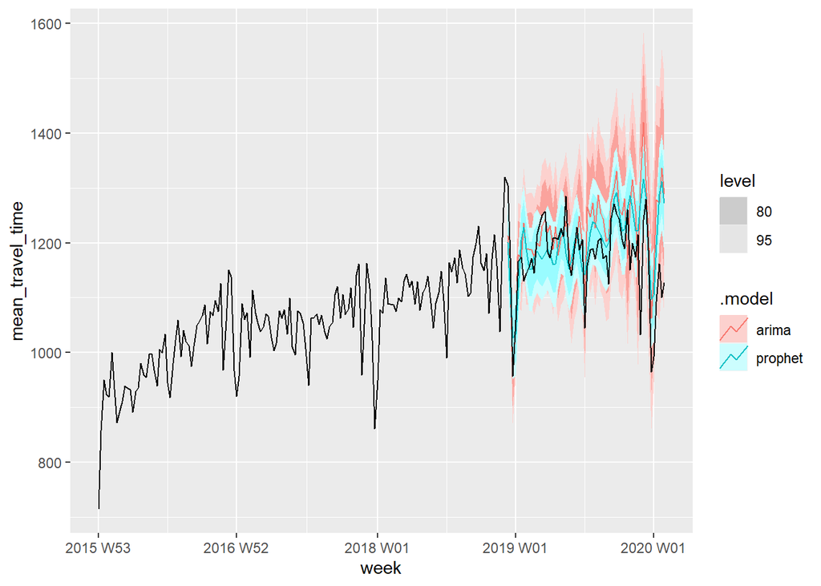

```r
fc_prop %>% autoplot(avg_times_week)
```

```r
fc_prop %>% accuracy(avg_times_week)
```

```
## # A tibble: 2 × 10
##   .model  .type    ME  RMSE   MAE   MPE  MAPE  MASE RMSSE  ACF1
##   <chr>   <chr> <dbl> <dbl> <dbl> <dbl> <dbl> <dbl> <dbl> <dbl>
## 1 arima   Test  -44.5  85.1  62.8 -3.99  5.47 0.881 0.997 0.340
## 2 prophet Test  -23.9  72.2  51.4 -2.28  4.52 0.722 0.845 0.439
```

## Prophet Decomposition & Forecasting

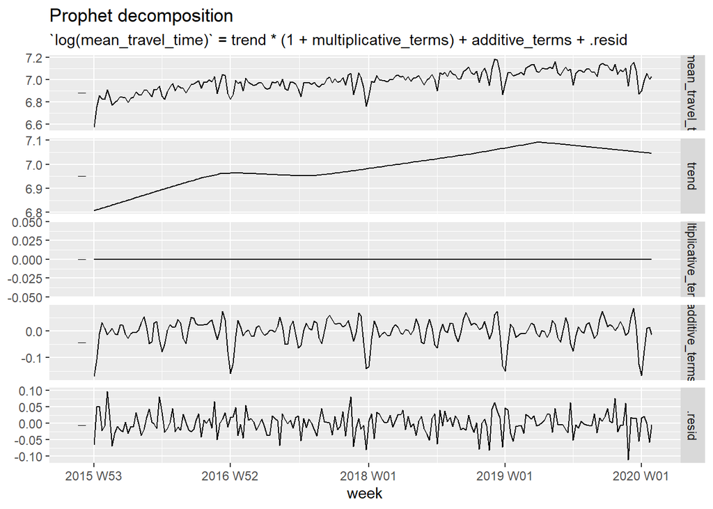

```r
fit_ph_dcmp <- avg_times_week %>% model(
  prophet(log(mean_travel_time) ~
            season(period = "month", order = 5) +
            season(period="year",order=10))
)

fit_ph_dcmp %>%
  components() %>%
  autoplot()
```

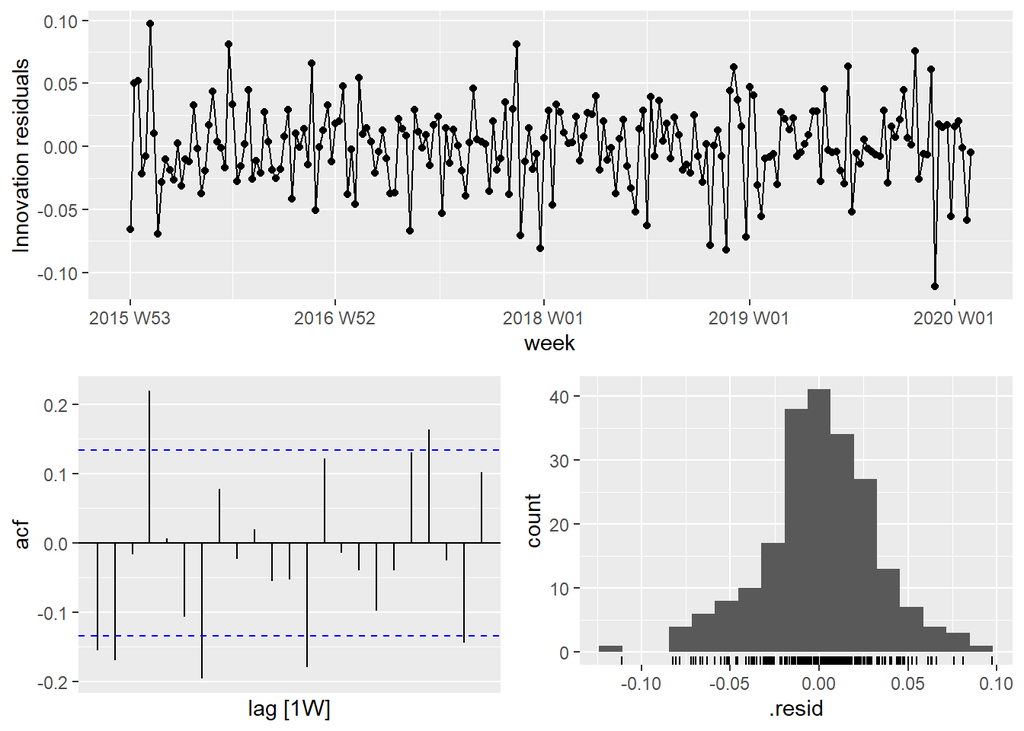

```r
fit_ph_dcmp %>% gg_tsresiduals()
```

## Prophet modelling on 90% training data

```r
test_rows = as.integer(((100-90)/100)*nrow(avg_times_week))
train <- slice(avg_times_week,1:(n()-test_rows))
#train <- as_tsibble(train,index=Date_parsed)
train <- fill_gaps(train,mean_travel_time = mean(mean_travel_time))
train
```

```
## # A tsibble: 193 x 4 [1W]
##        week mean_travel_time log_travel_time doubly_diff_travel_time
##      <week>            <dbl>           <dbl>                   <dbl>
##  1 2015 W53             714.              NA                      NA
##  2 2016 W01             858.              NA                      NA
##  3 2016 W02             950.              NA                      NA
##  4 2016 W03             923.              NA                      NA
##  5 2016 W04             920.              NA                      NA
##  6 2016 W05            1000.              NA                      NA
##  7 2016 W06             934.              NA                      NA
##  8 2016 W07             872.              NA                      NA
##  9 2016 W08             895.              NA                      NA
## 10 2016 W09             911.              NA                      NA
## # … with 183 more rows
```

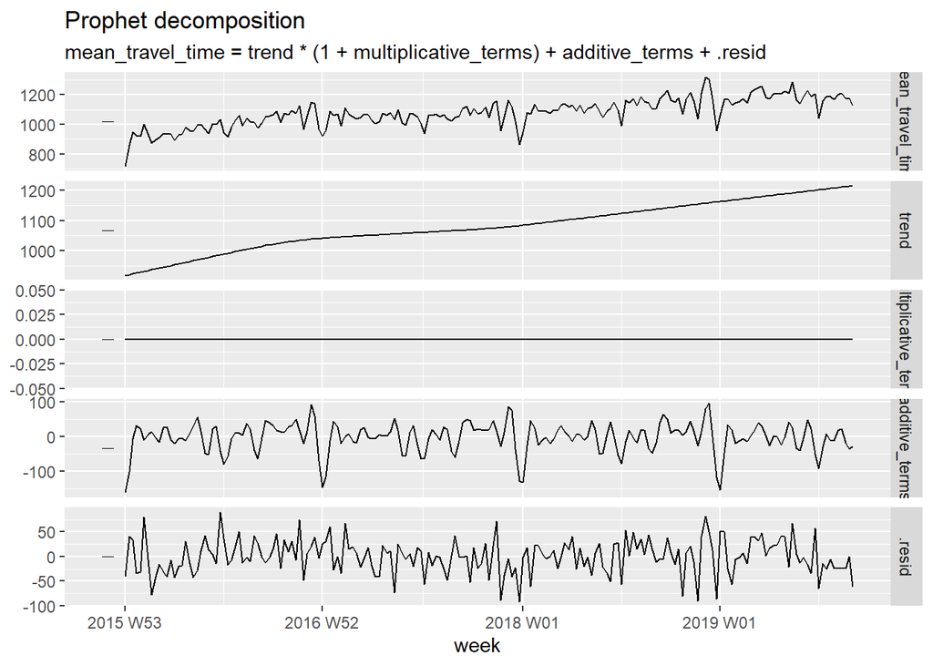

```r
fit_ph_dcmp <- train %>% model(
  prophet(mean_travel_time ~
            season(period = "month", order = 5) +
            season(period="year",order=10))
)

fit_ph_dcmp %>%
  components() %>%
  autoplot()
```

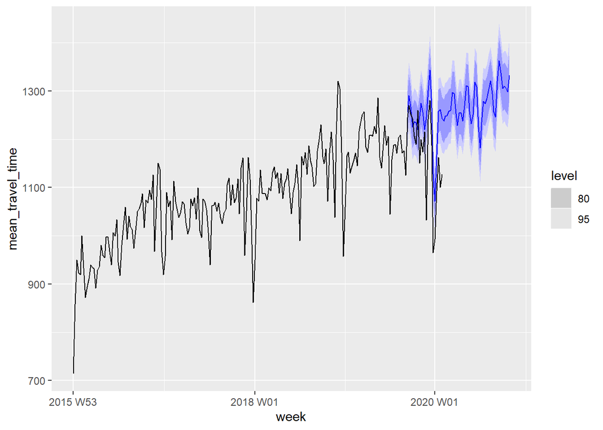

```r
fc_ph <- fit_ph_dcmp %>% forecast(h=60)

fc_ph %>% autoplot(avg_times_week)
```

```r
metrics <- fc_ph %>%
          accuracy(avg_times_week)
metrics %>% pivot_longer(!c(.model,.type),names_to="features",values_to="value") %>%
          select(features,value)
```

```
## # A tibble: 8 × 2
##   features   value
##   <chr>      <dbl>
## 1 ME       -68.0
## 2 RMSE      91.1
## 3 MAE       73.6
## 4 MPE       -6.16
## 5 MAPE       6.61
## 6 MASE       0.992
## 7 RMSSE      1.04
## 8 ACF1       0.156
```

Now we can forecast future mean travel times with Prophet.

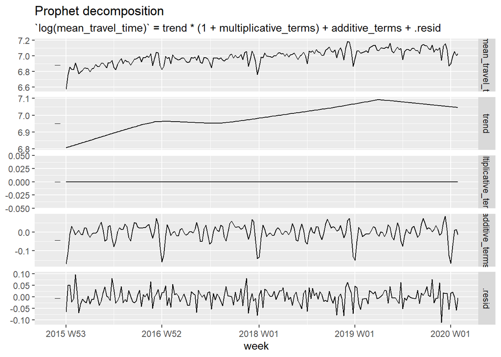

```r
fit_ph_dcmp <- avg_times_week %>% model(
  prophet(log(mean_travel_time) ~
            season(period = "month", order = 5) +
            season(period="year",order=10))
)

fit_ph_dcmp %>%
  components() %>%
  autoplot()
```

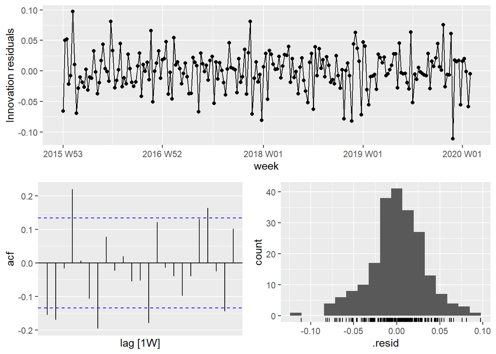

```r
fit_ph_dcmp %>% gg_tsresiduals()
```

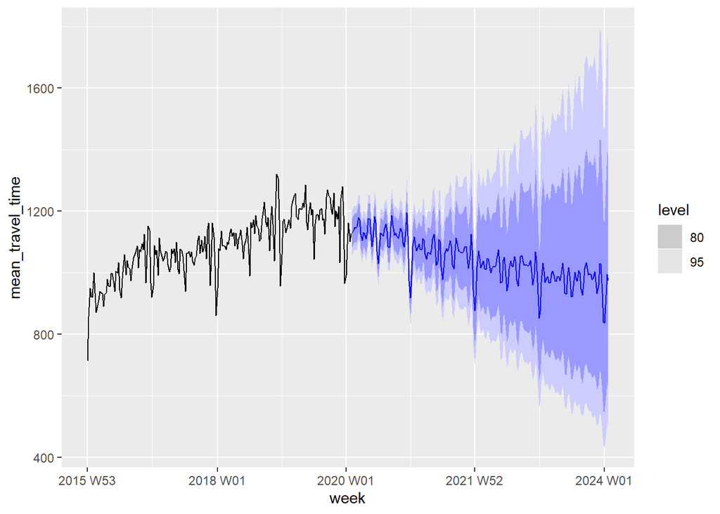

```r
fc_ph <- fit_ph_dcmp %>% forecast(h=208)

fc_ph %>% autoplot(avg_times_week)
```

Interestingly, here we can observe that Prophet is predicting a downward trend in the coming years as opposed to what ARIMA predicted. Prophet is also able to capture the correct yearly seasonality.

# Model Comparison - ARIMA, ETL, Prophet

```r
train <- slice(avg_times_week,1:(n()-60))
train <- as_tsibble(train,index=week)
train <- fill_gaps(train,mean_travel_time = mean(mean_travel_time))
```

```r
fit_compare <- train %>%
  model(
    arima = ARIMA(mean_travel_time),
    ets = ETS(mean_travel_time),
    prophet = prophet(log(mean_travel_time) ~ season(period = "month", order = 5) +
            season(period="year",order=10))
  )
fc <- fit_compare %>% forecast(h=60)
```

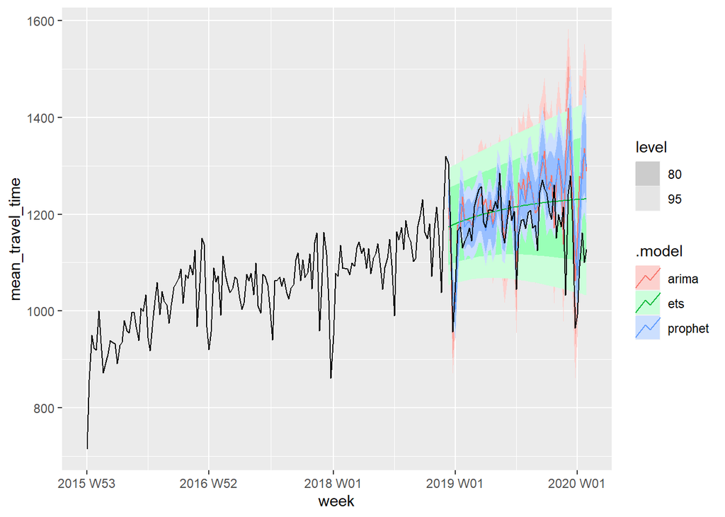

```r
fc %>% autoplot(avg_times_week)
```

```r
fc %>% accuracy(avg_times_week)
```

```
## # A tibble: 3 × 10
##   .model  .type    ME  RMSE   MAE   MPE  MAPE  MASE RMSSE  ACF1
##   <chr>   <chr> <dbl> <dbl> <dbl> <dbl> <dbl> <dbl> <dbl> <dbl>
## 1 arima   Test  -44.5  85.1  62.8 -3.99  5.47 0.881 0.997 0.340
## 2 ets     Test  -35.3  82.1  56.8 -3.43  5.12 0.797 0.962 0.386
## 3 prophet Test  -43.7  78.1  61.5 -3.91  5.38 0.863 0.915 0.494
```